# Introducció a l’estadística amb R

Sessió 2 · Estadística descriptiva i introducció a la inferència

Joel Ardiaca

Centre d’Estudis d’Opinió

27 d’octubre del 2026

# Benvinguda

## Què farem avui?

| Hora | Què farem |
| --- | --- |
| 9.30 | **Estadística descriptiva**: una mica de teoria, molt ràpida |
| 10.05 | **Pràctica**: acabar la pràctica 1 i afegir-hi descriptiva amb `summarise()` |
| 11.00 | *Pausa* |
| 11.30 | **Inferència**: les idees bàsiques |
| 12.15 | **Pràctica 2**: quatre coses d’inferència amb les mateixes dades |

A les slides trobareu enllaços 📖 **Per aprofundir**: documents opcionals, pensats per llegir pel vostre compte.

# Estadística descriptiva

## Què és l’estadística descriptiva?

- **Resumir** moltes dades amb pocs números (i algun gràfic)
- És el **primer pas** de qualsevol anàlisi: abans de treure conclusions, cal saber què tenim
- Què podem calcular depèn del **tipus de variable**:

| Tipus de variable | Què calculem | Amb R |
| --- | --- | --- |
| **Categòrica** (nominal) | Freqüències i percentatges, moda | `count()` |
| **Categòrica ordinal** | El mateix + percentatges **acumulats** | `count()` + `cumsum()` |
| **Quantitativa** | Mitjana, mediana, quartils, desviació típica… | `summarise()` |

## Variables categòriques: `count()`

Quants alumnes hi ha a cada categoria? (**freqüència absoluta**)

```r
competencies |>
  count(titularitat)
```

```
# A tibble: 2 × 2
  titularitat     n
  <chr>       <int>
1 Privat        163
2 Públic        317
```

I quin **percentatge** representen? Ho afegim amb `mutate()`:

```r
competencies |>
  count(titularitat) |>
  mutate(percentatge = n / sum(n) * 100)
```

```
# A tibble: 2 × 3
  titularitat     n percentatge
  <chr>       <int>       <dbl>
1 Privat        163        34.0
2 Públic        317        66.0
```

## Variables ordinals: percentatge acumulat

Si les categories tenen un **ordre**, podem anar sumant els percentatges amb `cumsum()`:

```r
competencies |>
  count(habitat) |>
  mutate(percentatge = n / sum(n) * 100,
         percentatge_acumulat = cumsum(percentatge))
```

```
# A tibble: 3 × 4
  habitat               n percentatge percentatge_acumulat
  <fct>             <int>       <dbl>                <dbl>
1 Fins a 10000        101        21.0                 21.0
2 De 10001 a 100000   212        44.2                 65.2
3 Més de 100000       167        34.8                100
```

**Com es llegeix?** El 65 % dels alumnes estudien en municipis de 100.000 habitants o menys. Només té sentit perquè `habitat` és un **factor ordenat**.

## Variables numèriques: quines mesures fem servir?

| Pregunta | Mesura | Amb R |
| --- | --- | --- |
| On és el **centre**? | Mitjana, mediana | `mean()`, `median()` |
| Com es **reparteixen** els valors? | Quartils, percentils | `quantile()` |
| Com d’**escampats** estan? | Desviació típica, interval interquartílic (IQR), rang | `sd()`, `IQR()`, `min()`, `max()` |

No cal memoritzar fórmules: cal saber **què vol dir** cada número.

## Mitjana i mediana

### Mitjana

- Sumem tots els valors i dividim pel nombre de valors
- **Sensible** als valors extrems

### Mediana

- El valor **del mig** quan ordenem les dades
- **No es veu afectada** pels extrems

**Exemple**: alçades de 5 persones (cm): 165, 168, 170, 172 i **210**

```r
alcades <- c(165, 168, 170, 172, 210)
mean(alcades)
```

```
[1] 177
```

```r
median(alcades)
```

```
[1] 170
```

Una sola persona molt alta «estira» la mitjana cap amunt. La mediana no es mou.

## Mitjana o mediana? Ens diuen com és la distribució

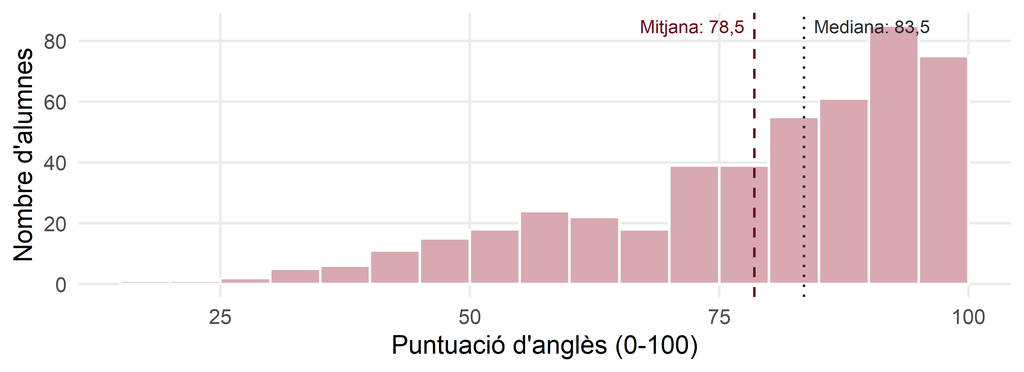

- **Mitjana < mediana**: hi ha una **cua a l’esquerra** (alguns alumnes amb notes molt baixes). És el cas de les notes d’anglès
- **Mitjana > mediana**: cua a la **dreta** (uns quants valors molt alts). És el cas típic dels **sous**

📖 **Per aprofundir**: la forma d’una distribució es pot mesurar amb l’**asimetria** i la **curtosi**. Ho trobareu a les slides de descriptiva de la sessió 1.

## Quartils: tallar les dades ordenades en quatre trossos

La mediana parteix les dades ordenades **en dues meitats**; els **quartils**, **en quatre quarts** (un 25 % a cada quart). Exemple amb 12 notes sobre 10, **ordenades**: 4 quarts de 3 notes.

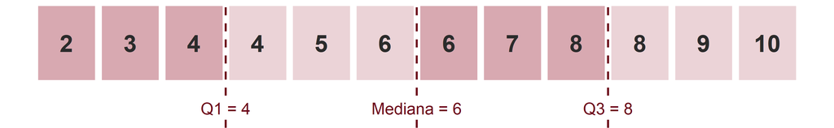

```r
notes <- c(2, 3, 4, 4, 5, 6,
           6, 7, 8, 8, 9, 10)
quantile(notes)
```

```
  0%  25%  50%  75% 100%
   2    4    6    8   10
```

- **$Q_1$ = 4**: entre la 3a i la 4a nota. Per sota, el quart **més baix** (2, 3 i 4)
- **$Q_2$ = 6**: la **mediana**, entre la 6a i la 7a nota
- **$Q_3$ = 8**: entre la 9a i la 10a. Per sobre, el quart **més alt** (8, 9 i 10)
- `0%` i `100%`: el **mínim** i el **màxim**

## Quartils amb les dades reals

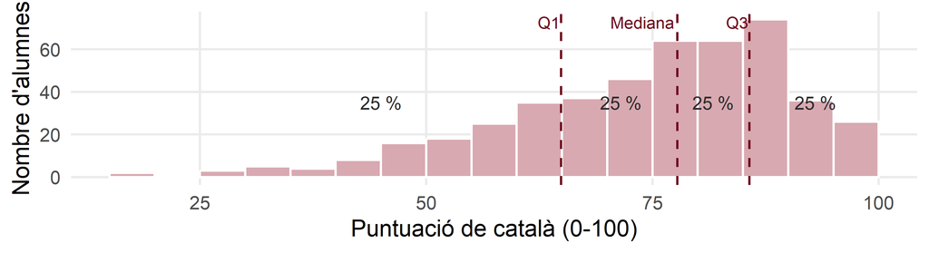

```r
quantile(competencies$nota_cat, na.rm = TRUE)
```

```
    0%    25%    50%    75%   100%
 18.20  64.90  77.75  85.70 100.00
```

Un 25 % dels alumnes treu menys de **64,9** punts, la meitat menys de **77,8**, i un 25 % més de **85,7**. Entre $Q_1$ i $Q_3$ hi ha **el 50 % central** dels alumnes.

## Percentils: el mateix, però en 100 trossos

- El **percentil $p$** és el valor que deixa **per sota el $p$ %** de les observacions
- Els quartils són percentils concrets: $Q_1$ = percentil 25, mediana = percentil 50, $Q_3$ = percentil 75
- Un exemple conegut: les **corbes de creixement** del pediatre. «El nen és al percentil 80 d’alçada» vol dir que és més alt que el 80 % dels nens de la seva edat

Amb R, triem quins percentils volem amb `probs` (en tant per u):

```r
quantile(competencies$nota_cat, probs = c(0.10, 0.90), na.rm = TRUE)
```

```
  10%   90%
52.01 91.90
```

**Com es llegeix?** El 10 % dels alumnes amb notes més baixes en català treu menys de 52,0 punts (percentil 10), i el 10 % amb notes més altes, més de 91,9 (percentil 90).

## Dispersió: com d’escampats estan els valors?

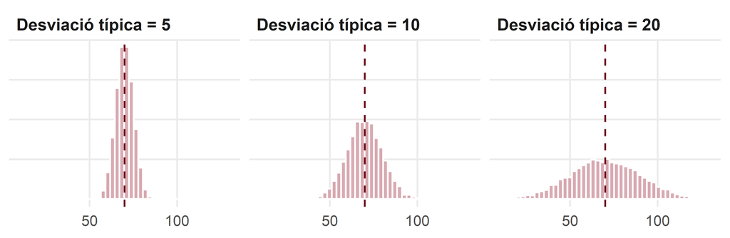

Tres grups amb la **mateixa mitjana** (70) i dispersió molt diferent. La mitjana sola no ho explica tot!

- **Desviació típica** (`sd()`): la distància «típica» dels valors respecte de la mitjana. Petita → valors agrupats; gran → valors escampats
- **Interval interquartílic** (`IQR()`): $Q_3 - Q_1$, l’amplada del 50 % central. No es veu afectat pels extrems

## Com es calcula la desviació típica? No és màgia

Alçades de **5 persones** (cm): 160, 170, 180, 165 i 175

| Alçada $x_i$ | Diferència amb la mitjana $x_i - \bar{x}$ | Al quadrat $(x_i - \bar{x})^2$ |
| --- | --- | --- |
| 160 | −10 | 100 |
| 170 | 0 | 0 |
| 180 | +10 | 100 |
| 165 | −5 | 25 |
| 175 | +5 | 25 |
| **Suma** | **0** | **250** |

```r
alcades2 <- c(160, 170, 180, 165, 175)
var(alcades2)   # variància
```

```
[1] 62.5
```

```r
sd(alcades2)    # desviació típica
```

```
[1] 7.905694
```

1. **Mitjana**: $\bar{x} = 850 / 5 = 170$
2. **Diferència** de cada persona amb la mitjana. Sumen 0: per això les elevem **al quadrat**
3. **Variància**: la «mitjana» dels quadrats
   $$s^2 = \frac{\sum (x_i - \bar{x})^2}{n - 1} = \frac{250}{4} = 62{,}5$$
4. **Desviació típica**: l’arrel quadrada, per tornar a les unitats originals (cm)
   $$s = \sqrt{62{,}5} \approx 7{,}9 \text{ cm}$$

Dividim per $n - 1$ (i no per $n$) perquè treballem amb una **mostra**: és el que fa R per defecte.

## Compte amb els valors perduts: `na.rm = TRUE`

16 alumnes **no tenen nota de català** (`NA`). Si en demanem la mitjana:

```r
mean(competencies$nota_cat)
```

```
[1] NA
```

R no pot sumar un valor desconegut i ens torna `NA`. Li hem de dir que **ignori els `NA`**:

```r
mean(competencies$nota_cat, na.rm = TRUE)
```

```
[1] 74.52069
```

`na.rm = TRUE` vol dir «treu els `NA`» (*NA remove*). Funciona igual a `median()`, `sd()`, `quantile()`, `IQR()`, `min()` i `max()`.

Quants n’hi ha? `sum(is.na(competencies$nota_cat))`

## Tot de cop: `summary()` i `summarise()`

```r
summary(competencies$nota_cat)
```

```
   Min. 1st Qu.  Median    Mean 3rd Qu.    Max.    NA's
  18.20   64.90   77.75   74.52   85.70  100.00      16
```

O a la nostra manera, triant què volem calcular:

```r
competencies |>
  summarise(mitjana     = mean(nota_cat, na.rm = TRUE),
            mediana     = median(nota_cat, na.rm = TRUE),
            q1          = quantile(nota_cat, 0.25, na.rm = TRUE),
            q3          = quantile(nota_cat, 0.75, na.rm = TRUE),
            desv_tipica = sd(nota_cat, na.rm = TRUE))
```

```
# A tibble: 1 × 5
  mitjana mediana    q1    q3 desv_tipica
    <dbl>   <dbl> <dbl> <dbl>       <dbl>
1    74.5    77.8  64.9  85.7        15.7
```

`summarise()` **resumeix moltes files en una sola**. Cada línia: `nom_que_vull = funcio(variable)`. A la sessió 3 hi afegirem `group_by()` per fer-ho **per grups**.

## El diagrama de caixa (*boxplot*)

Els **quartils** en un gràfic:

- La **caixa** va de $Q_1$ a $Q_3$: hi ha el 50 % central dels alumnes
- La **línia** del mig és la **mediana**
- Els **bigotis** arriben als valors «normals»
- Els **punts** són valors atípics (*outliers*)

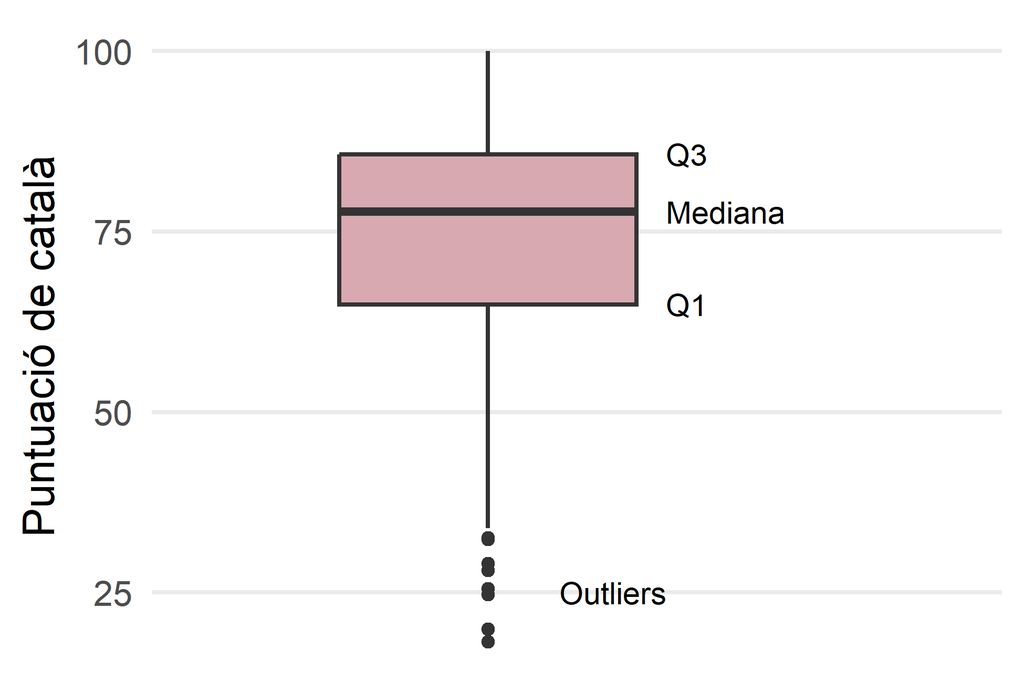

📖 **Per aprofundir**: per fer aquest gràfic i d’altres amb R, vegeu el tutorial de `ggplot2`.

## Abans de la pràctica: on treballa R?

- R sempre treballa des d’una carpeta: el **directori de treball**
- `getwd()` (*get working directory*) ens diu quina és:

```r
getwd()
```

```
#> "C:/Users/.../sessio-1"      ← ha d'acabar amb la carpeta del projecte
```

- Si obrim un **projecte** (`.Rproj`), el directori de treball és **la carpeta del projecte**
- Per això les rutes són curtes: `"dades/competencies_basiques.csv"` vol dir «la carpeta `dades` de dins del projecte»

**Error típic**: `'dades/...csv' does not exist in current working directory` vol dir que R no és a la carpeta del projecte. **Solució**: tanqueu RStudio i obriu el fitxer `.Rproj`.

## I `setwd()`?

`setwd()` (*set working directory*) canvia el directori de treball. **No el farem servir**:

### ❌ Amb `setwd()`

```r
setwd("C:/Users/anna/Documents/curs/sessio-1")
```

- Només funciona en **aquest** ordinador
- Si moveu o reanomeneu la carpeta, **falla**

### ✅ Amb un projecte

Doble clic a `sessio_1.Rproj`

- R ja és a la carpeta correcta
- Funciona a **qualsevol** ordinador
- No cal escriure cap ruta llarga

## Pas a pas: obrir els materials d’una sessió

1. Descarregueu el **zip** de la web del curs
2. **Descomprimiu-lo**: botó dret → *Extreu-ho tot*. No treballeu des de dins del zip!
3. Entreu a la carpeta descomprimida i feu **doble clic** a `sessio_N.Rproj`
4. Comproveu que a dalt a la dreta de RStudio hi diu **`sessio_N`**
5. Al panell *Files* (a baix a la dreta), obriu la carpeta `codi/` i l’script
6. Executeu `getwd()`: ha d’acabar en **`sessio-N`**

**Ara**: descarregueu i descomprimiu el zip de la **sessió 2**. Qui hagi d’acabar la pràctica 1, obriu el projecte de la **sessió 1** i el vostre `codi/exercici_sessio_1.R`.

# Pràctica: acabem la 1 i comencem la 2

## Pràctica: cadascú al seu ritme

**1. Acabar la pràctica 1**

Els **passos 1 a 10** (importar, netejar i exportar), al projecte de la **sessió 1**

**2. Pràctica 2, part A**

**Descriptiva** amb `count()` i `summarise()`, al projecte de la **sessió 2**

**3. Ja ho teniu?**

El tutorial de `ggplot2`: els vostres primers gràfics

- La part A es fa amb les dades **ja netes** de la sessió 2: no cal haver acabat la pràctica 1 per començar-la
- Lliurament: per una banda, la pràctica 1 (script i CSV); per l’altra, la pràctica 2 (parts A i B en un sol script)

**No vau arribar al pas 4 de la pràctica 1?** A la web de la sessió 2 teniu `exercici_sessio_1_passos_1-4.R`, amb els passos 1 a 4 ja fets. Deseu-lo a la carpeta `sessio-1/codi/`, obriu-lo des del panell *Files* i continueu des del pas 5.

## On érem? Passos 1 a 10

1. Carregar el `tidyverse` i **importar** amb `read_csv2()`
2. **Mirar** les dades amb `glimpse()`
3. `select()`: quedar-se amb `CODI_ALUMNE`, `GENERE`, `NATURALESA`, `HABITAT`, `PCAT`, `PMAT` i `PANG`
4. `rename()`: noms clars en minúscules (`id`, `genere`, `titularitat`, `habitat`, `nota_cat`…)
5. `mutate()` + `case_when()`: `D` → `"Dona"`, `H` → `"Home"`
6. `mutate()` + `factor()`: ordenar `habitat` de menys a més habitants
7. `mutate()`: crear `nota_mitjana` i `nivell_mat` (Baix < 50, Mitjà 50–75, Alt ≥ 75)
8. `filter()`: eliminar els alumnes sense nota de matemàtiques
9. Un **comentari** amb una limitació de les dades
10. **Exportar** amb `write_csv2()` a `dades/competencies_basiques_net.csv`

Feu-la **pas a pas**: escriviu una línia, executeu-la (Ctrl + Enter) i comproveu el resultat amb `glimpse()` abans de seguir.

## Pràctica 2 · Part A: descriptiva

Projecte de la **sessió 2** (`sessio_2.Rproj`), plantilla `codi/exercici_sessio_2.R` i dades `dades/competencies.csv`, ja netes: són exactament les que surten de la pràctica 1.

**Pas 1. Importar les dades** amb `read_csv2()` i tornar a ordenar `habitat` amb `factor()` (el CSV no guarda l’ordre).

**Pas 2. Freqüències de `habitat`**: absolutes, percentatges i acumulats. *Pista*: `count()` i `mutate()` amb `n / sum(n) * 100` i `cumsum()`. Quin percentatge estudia en municipis de 100.000 habitants o menys?

**Pas 3. Descriptiva de `nota_cat`** amb `summarise()`: mitjana, mediana, $Q_1$, $Q_3$, desviació típica i IQR. *Pista*: `na.rm = TRUE`. La mitjana és més alta o més baixa que la mediana? Què vol dir?

**Pas 4. Comparar les tres assignatures**: en un sol `summarise()`, la mitjana i la mediana de `nota_cat`, `nota_mat` i `nota_ang`. En quina s’obtenen les notes més altes?

Escriviu les respostes **en paraules**, amb comentaris (`#`). Les slides de descriptiva i `codi/01_descriptiva_inferencia.R` us fan de xuleta.

## Quan alguna cosa falla

R ens avisa a la **consola**. Els errors més habituals:

| Missatge | Què vol dir |
| --- | --- |
| `could not find function "read_csv2"` | No heu carregat el paquet: `library(tidyverse)` |
| `object 'competencies' not found` | No heu executat la línia que crea l’objecte, o el nom està mal escrit |
| `'dades/...' does not exist` | R no és a la carpeta del projecte (obriu el `.Rproj`) |
| `unexpected symbol` | Falta una coma, un parèntesi o un `\|>` |
| La consola mostra `+` i no passa res | Falta tancar un parèntesi o unes cometes: premeu **Esc** |
| El resultat és `NA` | Hi ha valors perduts: afegiu `na.rm = TRUE` |

## El teu torn (55’)

1. **Acabeu** la pràctica 1: passos 1 a 10 (projecte de la sessió 1)
2. **Pràctica 2, part A**: descriptiva, passos 1 a 4 (projecte de la sessió 2)
3. **Ja ho teniu tot?** Seguiu el tutorial de `ggplot2`

**Lliurament** per **correu electrònic** a joelardiacaarnau@gencat.cat:

- Pràctica 1: `exercici_sessio_1.R` (passos 1 a 10) i `competencies_basiques_net.csv`
- Pràctica 2: `exercici_sessio_2.R` (part A ara i part B després de la pausa)

Mentre treballeu aniré passant per les taules. Si us encalleu, aviseu!

## Correcció · Passos 1 a 4

```r
library(tidyverse)

# Pas 1: importar (CSV amb ; i coma decimal -> read_csv2)
competencies <- read_csv2("dades/competencies_basiques.csv")

# Pas 2: mirar les dades
glimpse(competencies)   # 500 files i 9 columnes

# Passos 3 i 4: seleccionar i reanomenar
competencies_net <- competencies |>
  select(CODI_ALUMNE, GENERE, NATURALESA, HABITAT, PCAT, PMAT, PANG) |>
  rename(id = CODI_ALUMNE, genere = GENERE, titularitat = NATURALESA,
         habitat = HABITAT, nota_cat = PCAT, nota_mat = PMAT, nota_ang = PANG)
```

`CODI_ALUMNE` és numèric, però no és una variable quantitativa: és un **identificador** (no té sentit fer-ne la mitjana).

## Correcció · Passos 5 a 10

```r
competencies_net <- competencies_net |>
  mutate(
    genere = case_when(genere == "D" ~ "Dona",                       # Pas 5
                       genere == "H" ~ "Home"),
    habitat = factor(habitat, levels = c("Fins a 10000",               # Pas 6
                                         "De 10001 a 100000",
                                         "Més de 100000")),
    nota_mitjana = (nota_cat + nota_mat + nota_ang) / 3,               # Pas 7
    nivell_mat = case_when(nota_mat < 50  ~ "Baix",
                           nota_mat < 75  ~ "Mitjà",
                           nota_mat >= 75 ~ "Alt")
  ) |>
  filter(!is.na(nota_mat))                                             # Pas 8

glimpse(competencies_net)   # queden 480 alumnes

write_csv2(competencies_net, "dades/competencies_basiques_net.csv")   # Pas 10
```

Pas 9 (limitació): els alumnes sense nota potser no falten a l’atzar; és una mostra (hi haurà marge d’error); una prova d’un dia no ho mesura tot…

# Pausa ☕

# Inferència

## De la mostra a la població

- Tenim **480 alumnes**, però volem parlar dels **73.431** alumnes de 6è de Catalunya
- La **inferència estadística** ens permet fer-ho… amb un **marge d’error**
- Com que treballem amb una **mostra**, sempre hi haurà **incertesa**. La bona notícia: la podem **quantificar**

**Exemple**: una enquesta del CEO a 2.000 persones per conèixer l’opinió de tota la població de Catalunya.

## El procés d’inferència estadística

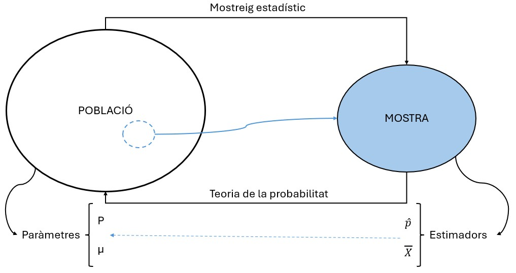

## Una mostra gran pot fallar: Landon vs. Roosevelt (1936)

- El *Literary Digest* va enviar **10 milions** de qüestionaris i va rebre **2,3 milions** de respostes
- Va predir una àmplia victòria del republicà Alf Landon
- George Gallup va enquestar **50.000** persones triades a l’atzar
- Va guanyar **Franklin D. Roosevelt** amb el 61 % del vot

**Què va fallar?**

La mostra sortia de llistes de telèfons i de subscriptors: una població **més rica i més conservadora**. No era una mostra **aleatòria**.

## Biaix i precisió

- Una mostra **no aleatòria** té **biaix**: apunta al lloc equivocat, per gran que sigui
- La **mida** de la mostra determina la **precisió**: com més gran, menys variació
- Necessitem totes dues coses: **aleatorietat** i **mida**

La qualitat de la mostra importa més que la mida.

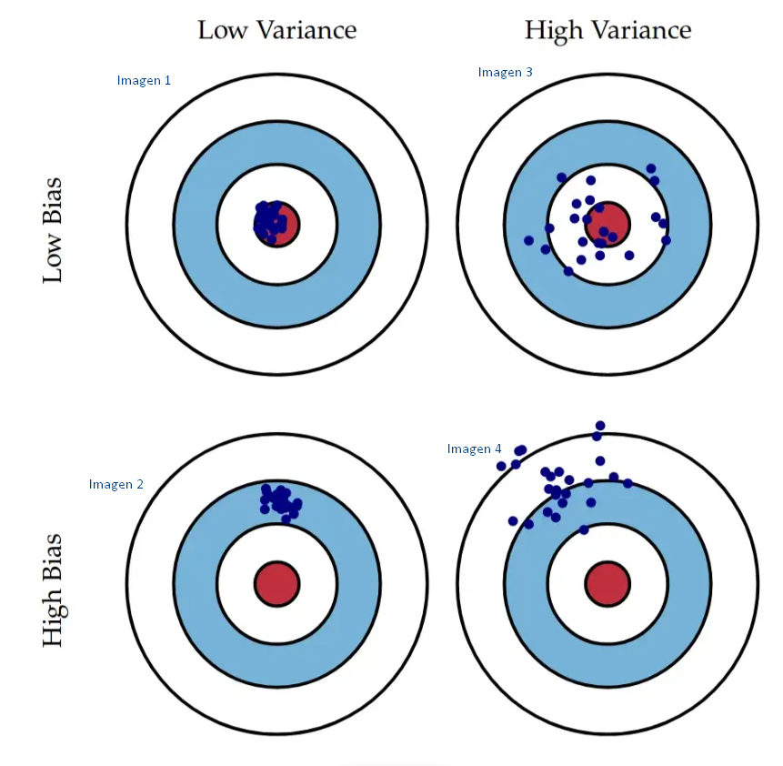

## Cada mostra dona un resultat diferent

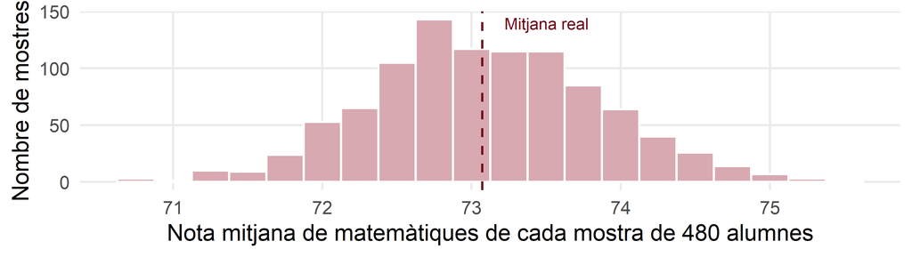

Si poguéssim repetir la mostra **1.000 vegades**, cada cop obtindríem una mitjana una mica diferent, però gairebé sempre a prop de la real. La variació d’aquestes mitjanes és l’**error estàndard**. I tenen forma de campana (**distribució normal**): per això funcionen els càlculs que farem.

📖 **Per aprofundir**: Per què cada mostra dona un resultat diferent · I si la població no és normal?

## Canviem de projecte

Ara passem a R. Tothom treballa ja amb el projecte de la **sessió 2**.

`dades/competencies.csv` és **el mateix fitxer** que s’exporta al pas 10 de la pràctica 1: 480 alumnes de 6è, amb les variables ja netes.

**Ara**: si encara sou al projecte de la sessió 1, tanqueu-lo. Obriu `sessio_2.Rproj` i després `codi/01_descriptiva_inferencia.R` (secció 3).

```r
library(tidyverse)
competencies <- read_csv2("dades/competencies.csv")
```

## L’error estàndard

Mesura **quant pot variar la nostra estimació** pel fet de treballar amb una mostra:

$$SE = \frac{\text{desviació típica}}{\sqrt{n}}$$

```r
competencies |>
  summarise(mitjana     = mean(nota_mat),
            desv_tipica = sd(nota_mat),
            n           = n(),
            se          = desv_tipica / sqrt(n))
```

```
# A tibble: 1 × 4
  mitjana desv_tipica     n    se
    <dbl>       <dbl> <int> <dbl>
1    73.6        17.5   480 0.800
```

- Com **més gran** és la mostra ($n$), **més petit** és l’error estàndard: més precisió
- Dins de `summarise()` podem fer servir les columnes que acabem de crear (`desv_tipica`, `n`)

## La regla del 95 %

- En una distribució **normal**, el **95 %** dels valors queden a menys de **1,96 desviacions típiques** del centre
- Aplicat a les mostres: en el 95 % dels casos, la mitjana de la mostra queda a menys de **1,96 errors estàndard** de la mitjana real

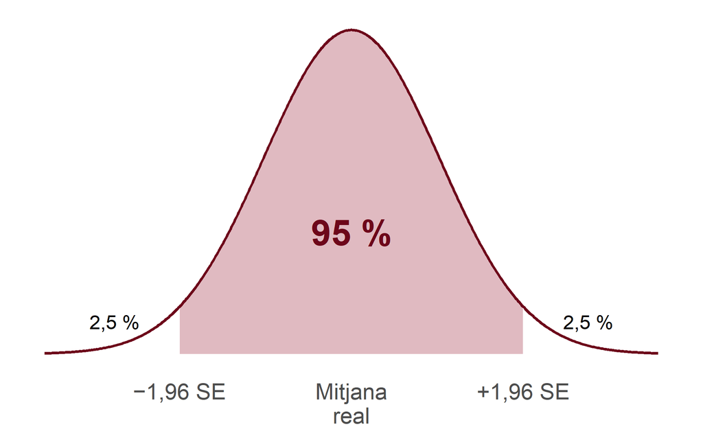

📖 **Per aprofundir**: La distribució normal i el valor z: d’on surt l’1,96

## Interval de confiança del 95 %

Un rang de valors on, amb un 95 % de confiança, hi ha el valor real de la població: $\text{mitjana} \pm 1{,}96 \cdot SE$

```r
competencies |>
  summarise(mitjana = mean(nota_mat),
            se      = sd(nota_mat) / sqrt(n()),
            inf     = mitjana - 1.96 * se,
            sup     = mitjana + 1.96 * se)
```

```
# A tibble: 1 × 4
  mitjana    se   inf   sup
    <dbl> <dbl> <dbl> <dbl>
1    73.6 0.800  72.0  75.1
```

**Com es llegeix?** Amb un 95 % de confiança, la nota mitjana de matemàtiques de **tots** els alumnes de 6è de Catalunya és entre 72,0 i 75,1 punts.

## Amb una sola comanda: `t.test()`

```r
t.test(competencies$nota_mat)$conf.int
```

```
[1] 72.01028 75.15347
attr(,"conf.level")
[1] 0.95
```

- Dona (pràcticament) el **mateix interval** que el nostre càlcul
- Fa servir la distribució *t* de Student en lloc de l’1,96: amb mostres grans, la diferència és mínima
- `$conf.int` vol dir «d’aquest resultat, dona’m només l’interval»
- **Ignora els `NA` automàticament**

📖 **Per aprofundir**: Què fa per dins `t.test()`?

## Què vol dir «95 % de confiança»?

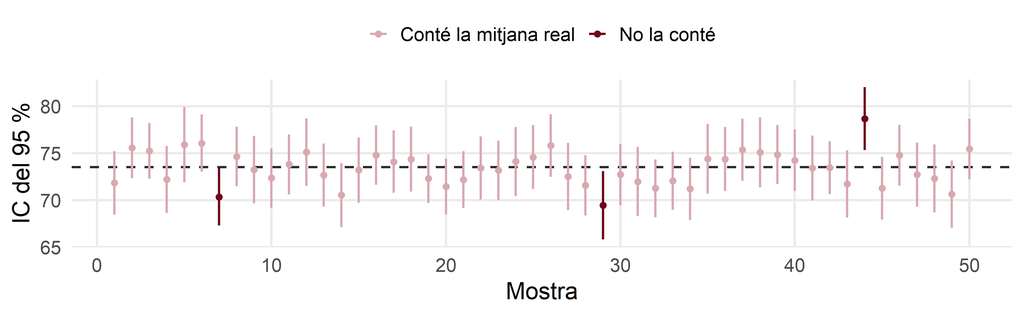

50 mostres, 50 intervals. Si repetíssim l’estudi moltes vegades, **el 95 % dels intervals contindrien la mitjana real**. El nostre és un d’aquests intervals: confiem que és dels «bons», però no ho podem saber del cert.

📖 **Per aprofundir**: Què vol dir «95 % de confiança»? (simulació)

## Més confiança = interval més ample

```r
t.test(competencies$nota_mat, conf.level = 0.90)$conf.int
```

```
[1] 72.26373 74.90002
attr(,"conf.level")
[1] 0.9
```

```r
t.test(competencies$nota_mat, conf.level = 0.99)$conf.int
```

```
[1] 71.51343 75.65032
attr(,"conf.level")
[1] 0.99
```

Per estar **més segurs** d’encertar, hem d’acceptar un interval **més ample** (menys precís). El 95 % és el nivell més habitual.

## Proporcions: el mateix raonament

Quin **percentatge** d’alumnes de Catalunya estudia en un centre **públic**? Primer, la proporció a la **mostra**, amb el que ja sabem fer:

```r
competencies |>
  count(titularitat) |>
  mutate(proporcio = n / sum(n))
```

```
# A tibble: 2 × 3
  titularitat     n proporcio
  <chr>       <int>     <dbl>
1 Privat        163     0.340
2 Públic        317     0.660
```

A la mostra, 317 dels 480 alumnes (el 66,0 %) van a un centre públic. Però és una **mostra**: a tot Catalunya, el percentatge real serà una mica diferent. Quant? Ho diu l’**interval de confiança**.

## Interval de confiança d’una proporció

L’**error estàndard** d’una proporció $p$ té una fórmula pròpia:

$$SE = \sqrt{\frac{p\,(1 - p)}{n}}$$

Amb les nostres dades:

$$SE = \sqrt{\frac{0{,}66 \cdot 0{,}34}{480}} \approx 0{,}022$$

I l’interval, com sempre: $p \pm 1{,}96 \cdot SE$

A R, ho fa tot `prop.test(casos, total)`, amb els números de la taula anterior:

```r
prop.test(317, 480)$conf.int
```

```
[1] 0.6158626 0.7023611
attr(,"conf.level")
[1] 0.95
```

**Com es llegeix?** Amb un 95 % de confiança, entre el 61,6 % i el 70,2 % dels alumnes de 6è de Catalunya van a un centre públic.

📖 **Per aprofundir**: Proporcions i distribució binomial

## Mida de la mostra i marge d’error

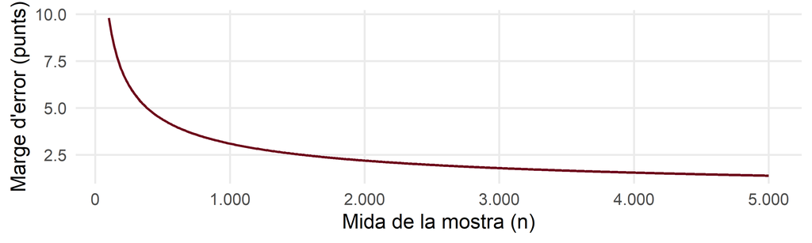

Marge d’error d’una enquesta (confiança del 95 %). Passar de 1.000 a 2.000 entrevistes **no** redueix el marge a la meitat: de ±3,1 a ±2,2 punts.

📖 **Per aprofundir**: d’on surt el marge d’error

## Contrast d’hipòtesis: la idea

Una pregunta de **sí o no**: la nota mitjana de matemàtiques a Catalunya, **és diferent de 72**?

- **Hipòtesi nul·la** ($H_0$): la mitjana **és** 72 (no hi ha diferència)
- **Hipòtesi alternativa** ($H_1$): la mitjana **no és** 72
- El **p-valor**: com de sorprenents serien les nostres dades **si $H_0$ fos certa**

Si el p-valor és **més petit que 0,05**, rebutgem $H_0$.

No demostrem res del cert: decidim si tenim **prou evidència** per rebutjar $H_0$. I el p-valor **no** és la probabilitat que $H_0$ sigui certa.

## Contrast d’hipòtesis amb R

```r
t.test(competencies$nota_mat, mu = 72)
```

```
    One Sample t-test

data:  competencies$nota_mat
t = 1.9778, df = 479, p-value = 0.04853
alternative hypothesis: true mean is not equal to 72
95 percent confidence interval:
 72.01028 75.15347
sample estimates:
mean of x
 73.58187
```

📖 **Per aprofundir**: d’on surten el *t* i el p-valor, a Què fa per dins `t.test()`?

## Llegir el resultat de `t.test()`

| Resultat | Què vol dir |
| --- | --- |
| `p-value` | 0,049, menor que 0,05 → **rebutgem $H_0$** |
| `alternative hypothesis` | Què estem contrastant: la mitjana és diferent de 72 |
| `95 percent confidence interval` | L’interval de confiança que ja coneixem |
| `mean of x` | La mitjana de la mostra: 73,6 |

**Conclusió**: les dades indiquen que la nota mitjana de matemàtiques **és diferent de 72** (més alta). Però per poc: el 72 queda **just fora** de l’interval de confiança (72,01–75,15).

## Interval i contrast diuen el mateix

- Si el valor de $H_0$ queda **fora** de l’interval del 95 % → p < 0,05 → **rebutgem** $H_0$
- Si queda **dins** de l’interval → p > 0,05 → **no podem rebutjar** $H_0$

```r
t.test(competencies$nota_mat, mu = 74)$p.value
```

```
[1] 0.6013745
```

El 74 és **dins** de l’interval (72,01–75,15): no tenim evidència que la mitjana sigui diferent de 74. Que no la puguem rebutjar **no vol dir** que la mitjana sigui exactament 74.

## Resum: quina comanda per a què?

| Vull… | Comanda |
| --- | --- |
| Freqüències i percentatges | `count(variable) \|> mutate(percentatge = n / sum(n) * 100)` |
| Mitjana, mediana, quartils, desviació… | `summarise(mitjana = mean(x, na.rm = TRUE), ...)` |
| Error estàndard | `summarise(se = sd(x) / sqrt(n()))` |
| Interval de confiança d’una mitjana | `t.test(dades$x)$conf.int` |
| Una proporció | `count(variable) \|> mutate(proporcio = n / sum(n))` |
| Interval de confiança d’una proporció | `prop.test(casos, total)$conf.int` |
| Contrast d’una mitjana | `t.test(dades$x, mu = valor)` |

# Pràctica 2

## Pràctica 2 · Part B: quatre coses d’inferència

Al mateix `codi/exercici_sessio_2.R`, a continuació de la part A. Treballarem amb la **nota de català** (`nota_cat`):

5. **Interval de confiança del 95 %** de la nota mitjana: a mà amb `summarise()` i amb `t.test()`
6. Intervals del **90 %** i del **99 %**. Quin és més ample? Per què?
7. **Una proporció**: quin percentatge d’alumnes té nivell `"Alt"` de matemàtiques? Interval de confiança amb `prop.test()`
8. **Un contrast**: la nota mitjana de català, és diferent de 75?

**Comenteu i interpreteu** cada resultat **en paraules** (amb `#` a l’script). Si no vau fer la part A, n’hi ha prou amb el pas 1 (importar les dades). Lliurament: l’script (parts A i B) per **correu electrònic** a joelardiacaarnau@gencat.cat.

## Ja heu acabat? Temes d’ampliació

Documents per llegir pel vostre compte, amb simulacions i gràfics, i amb el codi R plegat:

**Inferència**

1. La distribució normal i el valor z
2. Per què cada mostra dona un resultat diferent
3. I si la població no és normal? El teorema del límit central
4. Què fa per dins `t.test()`?
5. Què vol dir «95 % de confiança»?
6. Proporcions i distribució binomial

**Descriptiva i gràfics**

- Tutorial: primers gràfics amb `ggplot2`
- Slides de descriptiva de la sessió 1: asimetria, curtosi i com fer bons gràfics

Recomanació: llegiu-los **per ordre** (de l’1 al 6). Cada un acaba amb un resum de les idees clau.

# Tancament

## Què hem après avui?

### Descriptiva

- Freqüències i percentatges: `count()`
- Mitjana, mediana, quartils, desviació típica i IQR: `summarise()`
- Els `NA` i `na.rm = TRUE`
- Mitjana vs. mediana: la forma de la distribució

### Inferència

- Mostra i població: biaix i precisió
- Error estàndard
- Intervals de confiança: `t.test()`, `prop.test()`
- Contrast d’hipòtesis i p-valor

Propera sessió (dl. 2 de novembre): **comparar grups**. Dones i homes, centres públics i privats… són diferents?